# Project2_03

A.S

October 8, 2016

## **Disability Information by Age group in CT, MA and NY**

##### **The dataset for this project is downloaded from http://factfinder.census.gov/faces/tableservices/jsf/pages/productview.xhtml?src=bkmk. This is disability data for three states Connecticut, Massachusetts and New York. The data is group into 4 different categories based on the age group. The first is Under 5. The second group is between 5 and 17. The third group is between 18 and 64. And finally, the last group is for people aver 65 years of age. The dataset consists of different disabilities: Ambulatory, Cognitive, Hearing, Vision, Independent Living, Self care. For childer under 5, the data is available for only two disabilities Vision and Hearing.**

##### **The objective of this project is to analyze the disability data betwen age groups in three states, CT, MA and NY:**

##### **The following dplyr/tidyr functions are used in this project**

| **dplyr** | **tidyr** |
| --- | --- |
| **mutate** | **gather** |
| **filter** | **spread** |

##### **(1) Save the data as a CSV file:**

```r
library(tidyr)
library(dplyr)
library(stringr)
library(sqldf)
```

```r
library(ggplot2)
```

##### **(2) Read the information from the .CSV file into R, and use tidyr and dplyr as needed to tidy and transform your data:**

##### **(2.a) Read *03_DisabilityData.csv* file**

```r
disability_df = read.csv(file="03_DisabilityData.csv", header=TRUE, sep=",", skip = 0)
colnames(disability_df) = c("Age", "Disability_Type", "CT", "MA", "NY")
disability_df = filter(disability_df, Disability_Type != "")
print(disability_df)
```

```
##        Age    Disability_Type    CT     MA     NY
## 1   00--04            Hearing   990   1675   7937
## 2                      Vision   916   1446   6179
## 3   05--17            Hearing  3959   5549  15268
## 4                      Vision  5188   7754  18673
## 5                   Cognitive 21841  49995 109496
## 6                  Ambulatory  4750   7109  18549
## 7                   Self_care  6775  13008  28969
## 8   18--64            Hearing 36730  70648 185731
## 9                      Vision 25467  56577 172292
## 10                  Cognitive 82632 178639 420953
## 11                 Ambulatory 83191 171696 543684
## 12                  Self_care 31956  68609 189646
## 13         Independent_Living 63518 144643 370959
## 14 65--125            Hearing 63780 127943 312478
## 15                     Vision 26493  55416 161706
## 16                  Cognitive 38388  79919 232410
## 17                 Ambulatory 97804 190794 613547
## 18                  Self_care 36798  75502 245282
## 19         Independent_Living 72678 143724 437172
```

```r
print (colnames(disability_df))
```

```
## [1] "Age"             "Disability_Type" "CT"              "MA"              "NY"
```

##### **(2.b) If any row doesn’t have the Age, copy it over from previous row**

```r
for (i in 1:nrow(disability_df)) {
  if (disability_df$Age[i] == "") {
    disability_df$Age[i] = disability_df$Age[i-1]
  }
}
print(disability_df)
```

```
##        Age    Disability_Type    CT     MA     NY
## 1   00--04            Hearing   990   1675   7937
## 2   00--04             Vision   916   1446   6179
## 3   05--17            Hearing  3959   5549  15268
## 4   05--17             Vision  5188   7754  18673
## 5   05--17          Cognitive 21841  49995 109496
## 6   05--17         Ambulatory  4750   7109  18549
## 7   05--17          Self_care  6775  13008  28969
## 8   18--64            Hearing 36730  70648 185731
## 9   18--64             Vision 25467  56577 172292
## 10  18--64          Cognitive 82632 178639 420953
## 11  18--64         Ambulatory 83191 171696 543684
## 12  18--64          Self_care 31956  68609 189646
## 13  18--64 Independent_Living 63518 144643 370959
## 14 65--125            Hearing 63780 127943 312478
## 15 65--125             Vision 26493  55416 161706
## 16 65--125          Cognitive 38388  79919 232410
## 17 65--125         Ambulatory 97804 190794 613547
## 18 65--125          Self_care 36798  75502 245282
## 19 65--125 Independent_Living 72678 143724 437172
```

##### **(2.c) Apply tidyr *gather* function to change the data format from wide to long and change column names.**

```r
disability_df = gather(disability_df, State, Disability_Count, CT:NY)
print(disability_df)
```

```
##        Age    Disability_Type State Disability_Count
## 1   00--04            Hearing    CT              990
## 2   00--04             Vision    CT              916
## 3   05--17            Hearing    CT             3959
## 4   05--17             Vision    CT             5188
## 5   05--17          Cognitive    CT            21841
## 6   05--17         Ambulatory    CT             4750
## 7   05--17          Self_care    CT             6775
## 8   18--64            Hearing    CT            36730
## 9   18--64             Vision    CT            25467
## 10  18--64          Cognitive    CT            82632
## 11  18--64         Ambulatory    CT            83191
## 12  18--64          Self_care    CT            31956
## 13  18--64 Independent_Living    CT            63518
## 14 65--125            Hearing    CT            63780
```

[output cut: 43 more lines]

##### **(2.d) Apply tidyr *spread* function to spread data into multiple columns, one for each disability type.**

```r
disability_df = spread(disability_df, Disability_Type, Disability_Count)
disability_df[is.na(disability_df)] = 0
print (disability_df)
```

```
##        Age State Ambulatory Cognitive Hearing Independent_Living Self_care Vision
## 1   00--04    CT          0         0     990                  0         0    916
## 2   00--04    MA          0         0    1675                  0         0   1446
## 3   00--04    NY          0         0    7937                  0         0   6179
## 4   05--17    CT       4750     21841    3959                  0      6775   5188
## 5   05--17    MA       7109     49995    5549                  0     13008   7754
## 6   05--17    NY      18549    109496   15268                  0     28969  18673
## 7   18--64    CT      83191     82632   36730              63518     31956  25467
## 8   18--64    MA     171696    178639   70648             144643     68609  56577
## 9   18--64    NY     543684    420953  185731             370959    189646 172292
## 10 65--125    CT      97804     38388   63780              72678     36798  26493
## 11 65--125    MA     190794     79919  127943             143724     75502  55416
## 12 65--125    NY     613547    232410  312478             437172    245282 161706
```

##### **(2.e) Create a function to calculate the percentage and round it to 2 decimal digits**

```r
calcPercentage = function(value, totalValue) {
  round((value/totalValue)*100, 2)
}
```

##### **(2.f) Apply dplyr *mutate* function to add 7 extra columns for *TotalDisability*, *PercentAmbulatory* and *PercentCognitive* and*PercentHearing* and *PercentIndependent_Living* and *PercentSelf_care* and *PercentVision***

```r
disability_df = mutate(disability_df, TotalDisability=(Ambulatory+Cognitive+Hearing+Independent_Living+Self_care+Vision),
                        PercentAmbulatory=calcPercentage(Ambulatory, TotalDisability),
                        PercentCognitive=calcPercentage(Cognitive, TotalDisability),
                        PercentHearing=calcPercentage(Hearing, TotalDisability),
                        PercentIndependent_Living=calcPercentage(Independent_Living, TotalDisability),
                        PercentSelf_care=calcPercentage(Self_care, TotalDisability),
                        PercentVision=calcPercentage(Vision, TotalDisability))
print(disability_df)
```

```
##        Age State Ambulatory Cognitive Hearing Independent_Living Self_care Vision TotalDisability PercentAmbulatory PercentCognitive PercentHearing PercentIndependent_Living PercentSelf_care PercentVision
## 1   00--04    CT          0         0     990                  0         0    916            1906              0.00             0.00          51.94                      0.00             0.00         48.06
## 2   00--04    MA          0         0    1675                  0         0   1446            3121              0.00             0.00          53.67                      0.00             0.00         46.33
## 3   00--04    NY          0         0    7937                  0         0   6179           14116              0.00             0.00          56.23                      0.00             0.00         43.77
## 4   05--17    CT       4750     21841    3959                  0      6775   5188           42513             11.17            51.37           9.31                      0.00            15.94         12.20
## 5   05--17    MA       7109     49995    5549                  0     13008   7754           83415              8.52            59.94           6.65                      0.00            15.59          9.30
## 6   05--17    NY      18549    109496   15268                  0     28969  18673          190955              9.71            57.34           8.00                      0.00            15.17          9.78
## 7   18--64    CT      83191     82632   36730              63518     31956  25467          323494             25.72            25.54          11.35                     19.63             9.88          7.87
## 8   18--64    MA     171696    178639   70648             144643     68609  56577          690812             24.85            25.86          10.23                     20.94             9.93          8.19
## 9   18--64    NY     543684    420953  185731             370959    189646 172292         1883265             28.87            22.35           9.86                     19.70            10.07          9.15
## 10 65--125    CT      97804     38388   63780              72678     36798  26493          335941             29.11            11.43          18.99                     21.63            10.95          7.89
## 11 65--125    MA     190794     79919  127943             143724     75502  55416          673298             28.34            11.87          19.00                     21.35            11.21          8.23
## 12 65--125    NY     613547    232410  312478             437172    245282 161706         2002595             30.64            11.61          15.60                     21.83            12.25          8.07
```

##### **(3) Perform analysis to compare disabilities for different age groups.**

##### **(3.a) Draw a bar graph that represents the total number of disability for each state**

```r
disability_state_group_df=sqldf("select State, sum(TotalDisability) As TotalDisability from disability_df group by State")
print(disability_state_group_df)
```

```
##   State TotalDisability
## 1    CT          703854
## 2    MA         1450646
## 3    NY         4090931
```

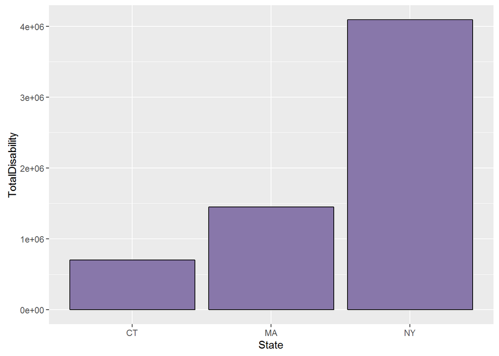

```r
ggplot(disability_state_group_df, aes(x=State, y=TotalDisability)) + geom_bar(fill="#8877aa", color="black", stat="identity")
```

##### **(3.b) Draw a bar graph that represents the total number of disability for each age group**

```r
disability_age_group_df=sqldf("select Age, sum(TotalDisability) As TotalDisability from disability_df group by Age")
print(disability_age_group_df)
```

```
##       Age TotalDisability
## 1  00--04           19143
## 2  05--17          316883
## 3  18--64         2897571
## 4 65--125         3011834
```

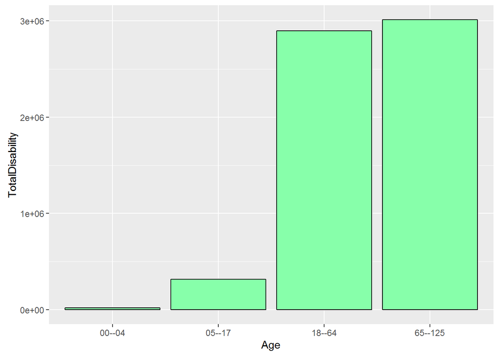

```r
ggplot(disability_age_group_df, aes(x=Age, y=TotalDisability)) + geom_bar(fill="#87ffaa", color="black", stat="identity")
```

##### **(3.c) Draw a bar graph that represents hearing disability for each state separated by each age group excluding age 0 to 4**

```r
graphHearing_df = filter (disability_df, (Age != "00--04"))
print(graphHearing_df)
```

```
##       Age State Ambulatory Cognitive Hearing Independent_Living Self_care Vision TotalDisability PercentAmbulatory PercentCognitive PercentHearing PercentIndependent_Living PercentSelf_care PercentVision
## 1  05--17    CT       4750     21841    3959                  0      6775   5188           42513             11.17            51.37           9.31                      0.00            15.94         12.20
## 2  05--17    MA       7109     49995    5549                  0     13008   7754           83415              8.52            59.94           6.65                      0.00            15.59          9.30
## 3  05--17    NY      18549    109496   15268                  0     28969  18673          190955              9.71            57.34           8.00                      0.00            15.17          9.78
## 4  18--64    CT      83191     82632   36730              63518     31956  25467          323494             25.72            25.54          11.35                     19.63             9.88          7.87
## 5  18--64    MA     171696    178639   70648             144643     68609  56577          690812             24.85            25.86          10.23                     20.94             9.93          8.19
## 6  18--64    NY     543684    420953  185731             370959    189646 172292         1883265             28.87            22.35           9.86                     19.70            10.07          9.15
## 7 65--125    CT      97804     38388   63780              72678     36798  26493          335941             29.11            11.43          18.99                     21.63            10.95          7.89
## 8 65--125    MA     190794     79919  127943             143724     75502  55416          673298             28.34            11.87          19.00                     21.35            11.21          8.23
## 9 65--125    NY     613547    232410  312478             437172    245282 161706         2002595             30.64            11.61          15.60                     21.83            12.25          8.07
```

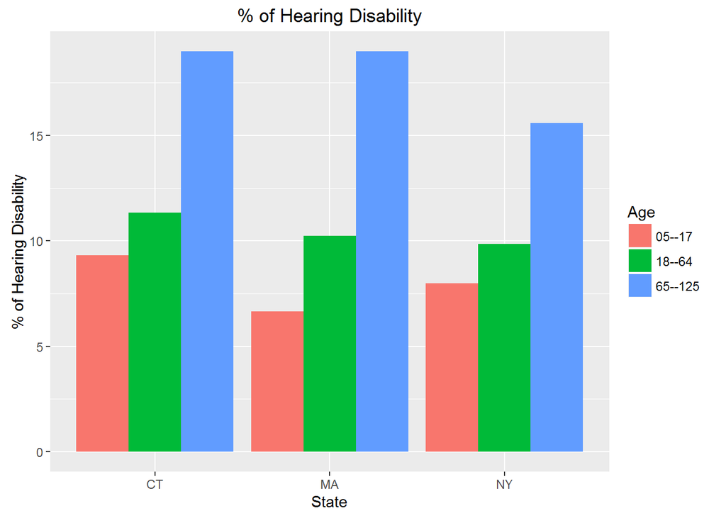

```r
ggplot(data=graphHearing_df, aes(x=State, y=PercentHearing, fill=Age)) + geom_bar(stat="identity", position="dodge") +
  ylab("% of Hearing Disability") + ggtitle("% of Hearing Disability")
```

##### **(3.d) Draw a bar graph that represents vision disability for each state separated by each age group excluding age 0 to 4**

```r
graphVision_df = filter (disability_df, (Age != "00--04"))
print(graphVision_df)
```

```
##       Age State Ambulatory Cognitive Hearing Independent_Living Self_care Vision TotalDisability PercentAmbulatory PercentCognitive PercentHearing PercentIndependent_Living PercentSelf_care PercentVision
## 1  05--17    CT       4750     21841    3959                  0      6775   5188           42513             11.17            51.37           9.31                      0.00            15.94         12.20
## 2  05--17    MA       7109     49995    5549                  0     13008   7754           83415              8.52            59.94           6.65                      0.00            15.59          9.30
## 3  05--17    NY      18549    109496   15268                  0     28969  18673          190955              9.71            57.34           8.00                      0.00            15.17          9.78
## 4  18--64    CT      83191     82632   36730              63518     31956  25467          323494             25.72            25.54          11.35                     19.63             9.88          7.87
## 5  18--64    MA     171696    178639   70648             144643     68609  56577          690812             24.85            25.86          10.23                     20.94             9.93          8.19
## 6  18--64    NY     543684    420953  185731             370959    189646 172292         1883265             28.87            22.35           9.86                     19.70            10.07          9.15
## 7 65--125    CT      97804     38388   63780              72678     36798  26493          335941             29.11            11.43          18.99                     21.63            10.95          7.89
## 8 65--125    MA     190794     79919  127943             143724     75502  55416          673298             28.34            11.87          19.00                     21.35            11.21          8.23
## 9 65--125    NY     613547    232410  312478             437172    245282 161706         2002595             30.64            11.61          15.60                     21.83            12.25          8.07
```

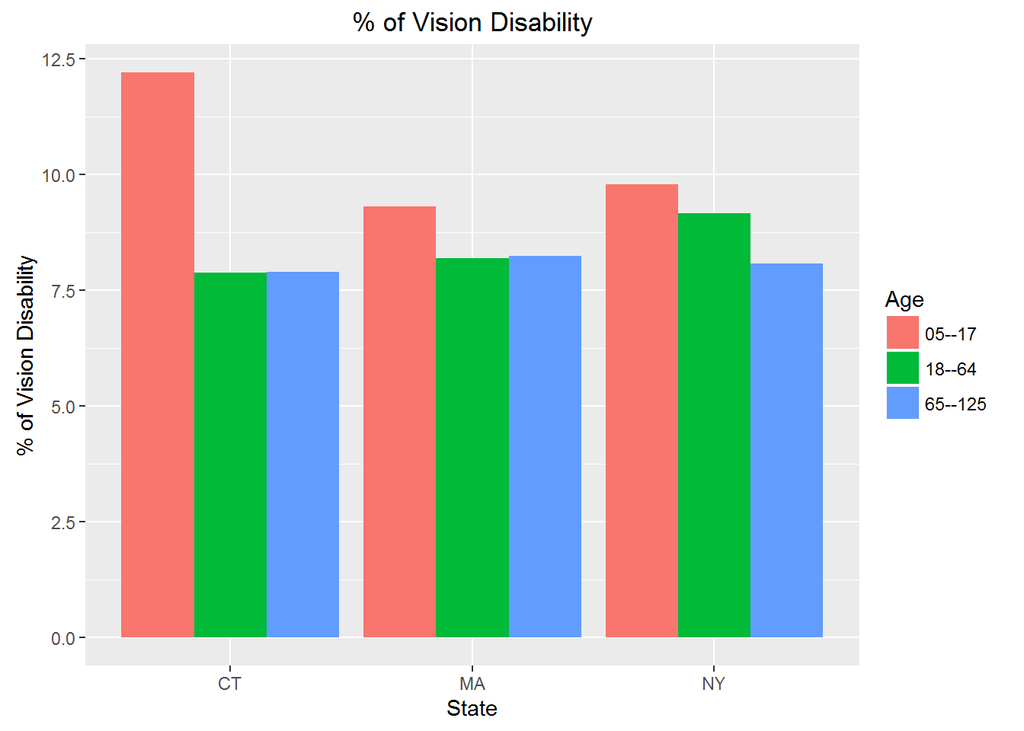

```r
ggplot(data=graphVision_df, aes(x=State, y=PercentVision, fill=Age)) + geom_bar(stat="identity", position="dodge") +
  ylab("% of Vision Disability") + ggtitle("% of Vision Disability")
```

##### **(3.e) Draw a line graph that represents ambulatory disability for each state separated by each age group excluding age 0 to 4**

```r
graphAmbulatory_df = filter (disability_df, (Age != "00--04"))
print(graphAmbulatory_df)
```

```
##       Age State Ambulatory Cognitive Hearing Independent_Living Self_care Vision TotalDisability PercentAmbulatory PercentCognitive PercentHearing PercentIndependent_Living PercentSelf_care PercentVision
## 1  05--17    CT       4750     21841    3959                  0      6775   5188           42513             11.17            51.37           9.31                      0.00            15.94         12.20
## 2  05--17    MA       7109     49995    5549                  0     13008   7754           83415              8.52            59.94           6.65                      0.00            15.59          9.30
## 3  05--17    NY      18549    109496   15268                  0     28969  18673          190955              9.71            57.34           8.00                      0.00            15.17          9.78
## 4  18--64    CT      83191     82632   36730              63518     31956  25467          323494             25.72            25.54          11.35                     19.63             9.88          7.87
## 5  18--64    MA     171696    178639   70648             144643     68609  56577          690812             24.85            25.86          10.23                     20.94             9.93          8.19
## 6  18--64    NY     543684    420953  185731             370959    189646 172292         1883265             28.87            22.35           9.86                     19.70            10.07          9.15
## 7 65--125    CT      97804     38388   63780              72678     36798  26493          335941             29.11            11.43          18.99                     21.63            10.95          7.89
## 8 65--125    MA     190794     79919  127943             143724     75502  55416          673298             28.34            11.87          19.00                     21.35            11.21          8.23
## 9 65--125    NY     613547    232410  312478             437172    245282 161706         2002595             30.64            11.61          15.60                     21.83            12.25          8.07
```

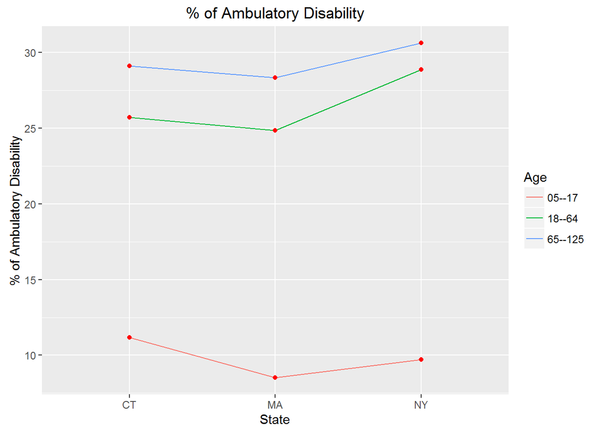

```r
ggplot(data=graphAmbulatory_df, aes(x=State, y=PercentAmbulatory, group=Age, color=Age)) +  geom_line() +
  geom_point(color = "Red") + ylab("% of Ambulatory Disability") + ggtitle("% of Ambulatory Disability")
```

##### **(3.f) Draw a line graph that represents cognitive disability for each state separated by each age group excluding age 0 to 4**

```r
graphCognitive_df = filter (disability_df, (Age != "00--04"))
print(graphCognitive_df)
```

```
##       Age State Ambulatory Cognitive Hearing Independent_Living Self_care Vision TotalDisability PercentAmbulatory PercentCognitive PercentHearing PercentIndependent_Living PercentSelf_care PercentVision
## 1  05--17    CT       4750     21841    3959                  0      6775   5188           42513             11.17            51.37           9.31                      0.00            15.94         12.20
## 2  05--17    MA       7109     49995    5549                  0     13008   7754           83415              8.52            59.94           6.65                      0.00            15.59          9.30
## 3  05--17    NY      18549    109496   15268                  0     28969  18673          190955              9.71            57.34           8.00                      0.00            15.17          9.78
## 4  18--64    CT      83191     82632   36730              63518     31956  25467          323494             25.72            25.54          11.35                     19.63             9.88          7.87
## 5  18--64    MA     171696    178639   70648             144643     68609  56577          690812             24.85            25.86          10.23                     20.94             9.93          8.19
## 6  18--64    NY     543684    420953  185731             370959    189646 172292         1883265             28.87            22.35           9.86                     19.70            10.07          9.15
## 7 65--125    CT      97804     38388   63780              72678     36798  26493          335941             29.11            11.43          18.99                     21.63            10.95          7.89
## 8 65--125    MA     190794     79919  127943             143724     75502  55416          673298             28.34            11.87          19.00                     21.35            11.21          8.23
## 9 65--125    NY     613547    232410  312478             437172    245282 161706         2002595             30.64            11.61          15.60                     21.83            12.25          8.07
```

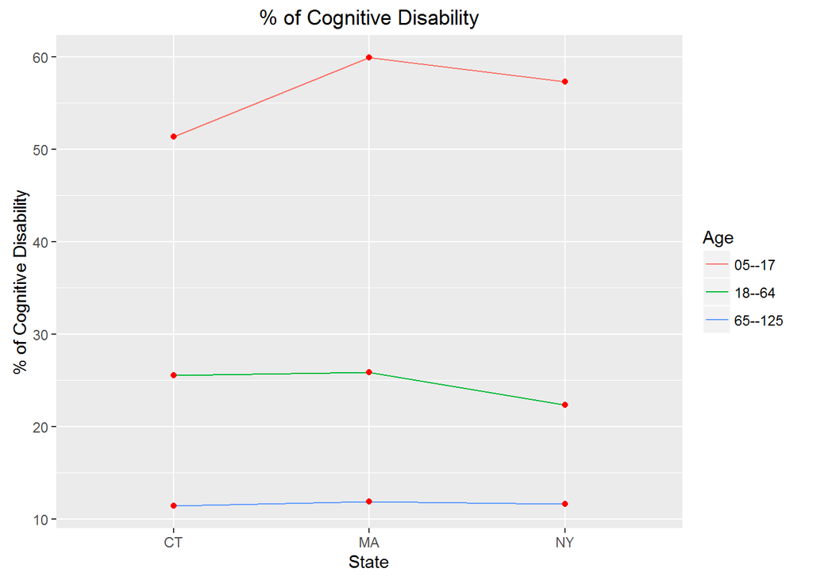

```r
ggplot(data=graphCognitive_df, aes(x=State, y=PercentCognitive, group=Age, color=Age)) +  geom_line() +
  geom_point(color = "Red") + ylab("% of Cognitive Disability") + ggtitle("% of Cognitive Disability")
```

##### **(4) Conclusion.**

**(4.a) From the graphs we can conclude that CT and MA have almost equal percentage of people with hearing disabilities in the age group 65 and over. And we also notice that CT has the highest percentage of children with the hearing disability in the age group 5-17 years.**

**From the first graph we can conclude that NY has the highest number of people with disabilities combined. This includes all age groups. Also, CT has the highest percentag of childern with Vision disability in the age group 5-17 years even though CT represents smaller population compared to NY.**